# MUSA 507 Final Project: Predicting Heroin Overdose Events in Cincinnati, OH

# Accuracy

When the model is trained on data from 2015-2018, we find that it predicts close to observed values in all deciles of heroin overdose, with a tendency to overpredict. The prediction error, on average, is approximately +/-6 overdose events, as seen in the Mean Absolute Error table below.

```r
  # Kable/Table of MAE.
  st_set_geometry(reg.summary, NULL) %>%
  #group_by(Regression) %>%
  summarize(MAE = round(mean(abs(Prediction - countHeroinResponses), na.rm = T),2)) %>%
            #,
            #SD_MAE = round(sd(abs(Prediction - countHeroinResponses), na.rm = T),2)) %>%
  kable(caption = "MAE by regression") %>%
  kable_styling("striped", full_width = F) %>%
  row_spec(1, color = "black", background = "#FDE725FF")
```

MAE by regression

| MAE |
| --- |
| 5.88 |

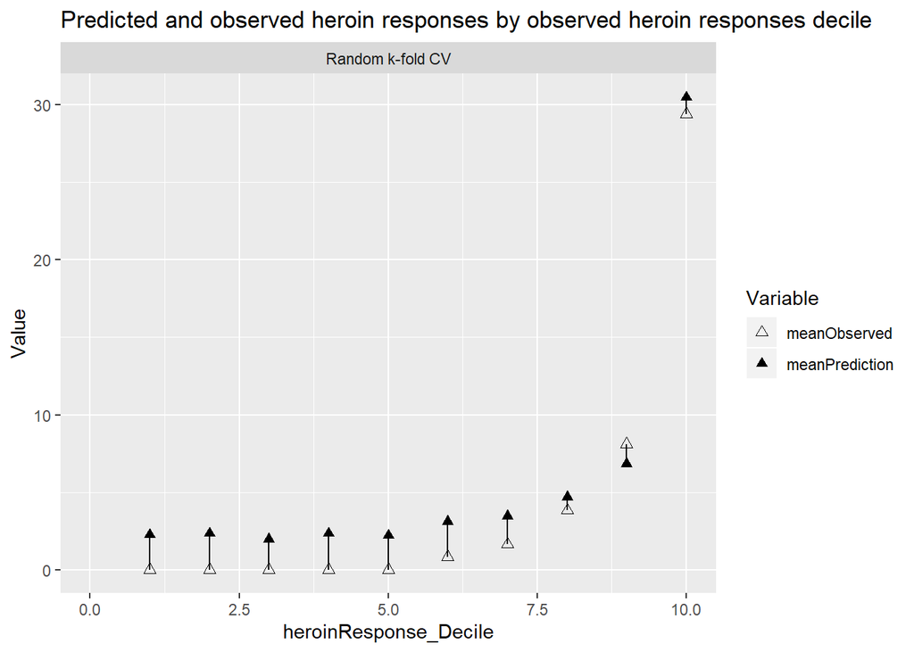

```r
  # Predicted and observed heroin responses by observed heroin responses decile
  st_set_geometry(reg.summary, NULL) %>%
    group_by(Regression) %>%
    mutate(heroinResponse_Decile = ntile(countHeroinResponses, 10)) %>%
    group_by(Regression, heroinResponse_Decile) %>%
    summarize(meanObserved = mean(countHeroinResponses, na.rm=T),
              meanPrediction = mean(Prediction, na.rm=T)) %>%
    gather(Variable, Value, -Regression, -heroinResponse_Decile) %>%
    ggplot(aes(heroinResponse_Decile, Value, shape = Variable)) +
    geom_point(size = 2) + geom_path(aes(group = heroinResponse_Decile), colour = "black") +
    scale_shape_manual(values = c(2, 17)) +
    facet_wrap(~Regression) + xlim(0,10) +
    labs(title = "Predicted and observed heroin responses by observed heroin responses decile")
```

# Generalizability

Our model-building process focused on factors that are correlated with heroin overdose per the drug abuse academic literature and popular report. Factor selection was influenced by the higher heroin overdose rate among White men than men of other racial/ethnic groups, and this likely introduced bias into the model, as seen by the much greater mean absolute error for majority-Nonwhite neighborhoods in Cincinnati (+/- 4 overdose events, on average) than for majority-White neighborhoods (close to zero, on average).

```r
tracts17 <-
  get_acs(geography = "tract", variables = c("B01001_001E","B01001A_001E"),
          year = 2017, state=39, county=061, geometry=T) %>%
  st_transform(3735)  %>%
  dplyr::select(variable, estimate, GEOID) %>%
  spread(variable, estimate) %>%
  rename(TotalPop = B01001_001,
         NumberWhites = B01001A_001) %>%
  mutate(percentWhite = NumberWhites / TotalPop,
         raceContext = ifelse(percentWhite > .5, "Majority_White", "Majority_Non_White")) %>%
  .[sna,]
```

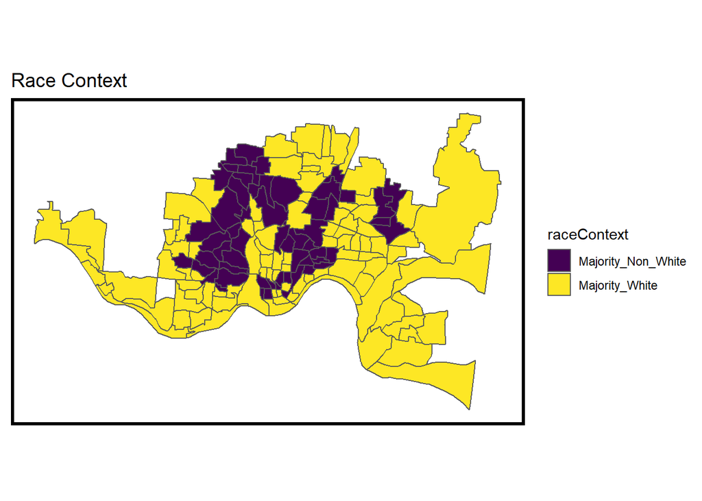

```r
ggplot() +
  geom_sf(data = tracts17, aes(fill = raceContext)) +
  scale_fill_viridis(discrete = TRUE) +
  labs(title = "Race Context", name="Race Context") +
  mapTheme()
```

```r
# Mean error by neighborhood context
final_reg <-
  reg.summary %>%
  mutate(uniqueID = rownames(.))

final_reg.tracts <-
  st_join(st_centroid(final_reg), tracts17) %>%
  st_set_geometry(NULL) %>%
  left_join(dplyr::select(final_reg, uniqueID)) %>%
  st_sf() %>%
  na.omit()

st_set_geometry(final_reg.tracts, NULL) %>%
  group_by(Regression, raceContext) %>%
  summarize(mean.Error = mean(Error, na.rm = T)) %>%
  spread(raceContext, mean.Error) %>%
  kable(caption = "Mean Error by neighborhood racial context") %>%
  kable_styling("striped", full_width = F)
```

Mean Error by neighborhood racial context

| Regression | Majority_Non_White | Majority_White |
| --- | --- | --- |
| Random k-fold CV | 4.044812 | -0.1895312 |

# Robustness checks

As indicated, the model appears to suffer from a focus on particular types of heroin users. Per the earlier evidence, it predicts well in lower-risk areas but is not generalizable across high-risk areas and is in fact outperformed by traditional kernel density “hotspot” methods.

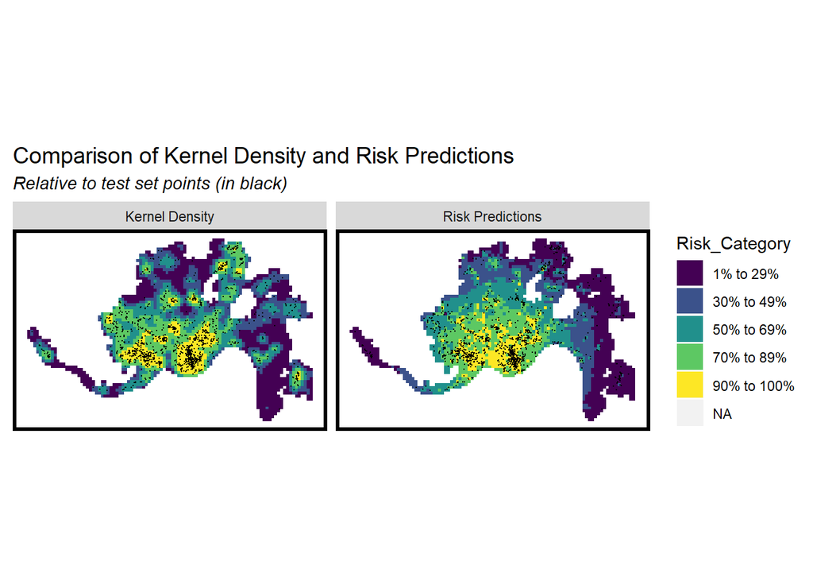

```r
  heroin_ppp <- as.ppp(st_coordinates(heroin_train), W = st_bbox(final_net))
  heroin_KD.1000 <- spatstat::density.ppp(heroin_ppp, 1000)
  heroin_KD.1500 <- spatstat::density.ppp(heroin_ppp, 1500)
  heroin_KD.2000 <- spatstat::density.ppp(heroin_ppp, 2000)
  heroin_KD.df <- rbind(
    mutate(data.frame(rasterToPoints(mask(raster(heroin_KD.1000), as(sna, 'Spatial')))), Legend = "1000 Ft."),
    mutate(data.frame(rasterToPoints(mask(raster(heroin_KD.1500), as(sna, 'Spatial')))), Legend = "1500 Ft."),
    mutate(data.frame(rasterToPoints(mask(raster(heroin_KD.2000), as(sna, 'Spatial')))), Legend = "2000 Ft."))

  heroin_KD.df$Legend <- factor(heroin_KD.df$Legend, levels = c("1000 Ft.", "1500 Ft.", "2000 Ft."))

  # ggplot(data=heroin_KD.df, aes(x=x, y=y)) +
  #   geom_raster(aes(fill=layer)) +
  #   facet_wrap(~Legend) +
  #   coord_sf(crs=st_crs(final_net)) +
  #   scale_fill_viridis() +
  #   mapTheme()

  heroin_ppp <- as.ppp(st_coordinates(heroin_train), W = st_bbox(final_net))
  heroin_KD <- spatstat::density.ppp(heroin_ppp, 1000)

  # as.data.frame(heroin_KD) %>%
  #   st_as_sf(coords = c("x", "y"), crs = st_crs(final_net)) %>%
  #   aggregate(., final_net, mean) %>%
  #   ggplot() +
  #   geom_sf(aes(fill=value)) +
  #   geom_sf(data = sample_n(heroin_train, 1500), size = .5) +
  #   scale_fill_viridis() +
  #   mapTheme()

  # Compute kernel density
  heroin_ppp <- as.ppp(st_coordinates(heroin_train), W = st_bbox(final_net))
  heroin_KD <- spatstat::density.ppp(heroin_ppp, 1000)
  # Convert kernel density to grid cells taking the mean
  heroin_KDE_sf <- as.data.frame(heroin_KD) %>%
    st_as_sf(coords = c("x", "y"), crs = st_crs(final_net)) %>%
    aggregate(., final_net, mean) %>%
    #Mutate the Risk_Category field as defined below.
    mutate(label = "Kernel Density",
           Risk_Category = ntile(value, 100),
           Risk_Category = case_when(
             Risk_Category >= 90 ~ "90% to 100%",
             Risk_Category >= 70 & Risk_Category <= 89 ~ "70% to 89%",
             Risk_Category >= 50 & Risk_Category <= 69 ~ "50% to 69%",
             Risk_Category >= 30 & Risk_Category <= 49 ~ "30% to 49%",
             Risk_Category >= 1 & Risk_Category <= 29 ~ "1% to 29%")) %>%
    #Bind to a layer where test set crime counts are spatially joined to the fisnnet.
    bind_cols(
      aggregate(
        dplyr::select(heroin_train) %>% mutate(heroinCount = 1), ., length) %>%
        mutate(heroinCount = replace_na(heroinCount, 0))) %>%
    #Select the fields we need
    dplyr::select(label, Risk_Category, heroinCount)

  # Repeat for the risk predictions (our model, not kernel density)
  heroin_risk_sf <-
    final_reg %>%
    mutate(label = "Risk Predictions",
           Risk_Category = ntile(Prediction, 100),
           Risk_Category = case_when(
             Risk_Category >= 90 ~ "90% to 100%",
             Risk_Category >= 70 & Risk_Category <= 89 ~ "70% to 89%",
             Risk_Category >= 50 & Risk_Category <= 69 ~ "50% to 69%",
             Risk_Category >= 30 & Risk_Category <= 49 ~ "30% to 49%",
             Risk_Category >= 1 & Risk_Category <= 29 ~ "1% to 29%")) %>%
    bind_cols(
      aggregate(
        dplyr::select(heroin_train) %>% mutate(heroinCount = 1), ., length) %>%
        mutate(heroinCount = replace_na(heroinCount, 0))) %>%
    dplyr::select(label,Risk_Category, heroinCount)

  # Geographical comparison
  rbind(heroin_KDE_sf, heroin_risk_sf) %>%
    gather(Variable, Value, -label, -Risk_Category, -geometry) %>%
    ggplot() +
    geom_sf(aes(fill = Risk_Category), colour = NA) +
    geom_sf(data = sample_n(heroin_train, 1500), size = .1, colour = "black") +
    facet_wrap(~label, ) +
    scale_fill_viridis(discrete = TRUE) +
    labs(title="Comparison of Kernel Density and Risk Predictions",
         subtitle="Relative to test set points (in black)") +
    mapTheme()
```

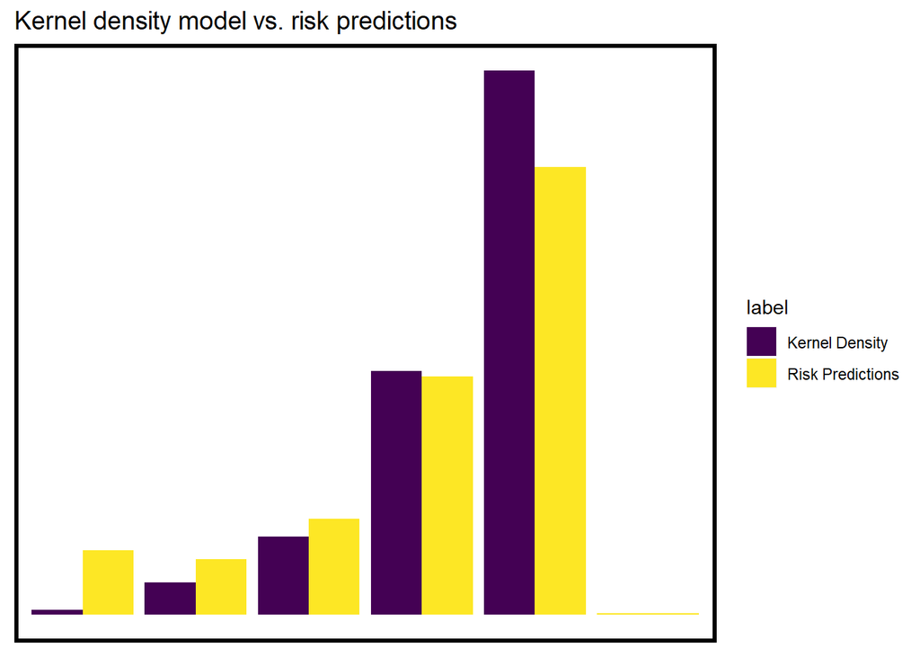

```r
  # Bar plot comparison
  rbind(heroin_KDE_sf, heroin_risk_sf) %>%
    st_set_geometry(NULL) %>%
    gather(Variable, Value, -label, -Risk_Category) %>%
    group_by(label, Risk_Category) %>%
    summarize(countHeroinResponses = sum(Value)) %>%
    ungroup() %>%
    group_by(label) %>%
    mutate(Rate_of_test_set_crimes = countHeroinResponses / sum(countHeroinResponses)) %>%
    ggplot(aes(Risk_Category,Rate_of_test_set_crimes)) +
    geom_bar(aes(fill=label), position="dodge", stat="identity") +
    scale_fill_viridis(discrete = TRUE) +
    labs(title = "Kernel density model vs. risk predictions") +
    mapTheme()
```